# Bilirubin concentrations and Ascities levels in Primary Biliary Cirrhosis.

## 0.1 Preliminaries

```r
library(skimr)
library(rms)
library(simputation)
library(broom)
library(modelr)
library(arm)
library(pander)
library(ROCR)
library(pROC)
library(forcats)
library(car)
library(tidyverse)
```

# 1 Task 1: Data Source

This dataset was found in appendix D of Fleming and Harrington, Counting Processes and Survival Analysis, Wiley, 1991. I have taken it from http://lib.stat.cmu.edu/datasets/ The dataset contains the data from the Mayo Clinic trial in primary biliary cirrhosis (PBC) of the liver conducted between 1974 and 1984.

A total of 424 PBC patients, referred to Mayo Clinic during that ten-year interval, met eligibility criteria for the randomized placebo controlled trial of the drug D-penicillamine. The first 312 cases in the data set participated in the randomized trial and contain largely complete data. The additional 112 cases did not participate in the clinical trial, but consented to have basic measurements recorded and to be followed for survival. Six of those cases were lost to follow-up shortly after diagnosis, so the data here are on an additional 106 cases as well as the 312 randomized participants. Missing data items are denoted by `.’. Thus, since many of the values were missing for last 112 people, I chose the first 312 values for the project. A more extended discussion can be found in Dickson, et al., Hepatology 10:1-7 (1989) and in Markus, et al., N Eng J of Med 320:1709-13 (1989).

# 2 Task 2: Load and Tidy the Data

```r
pbc <- read.csv("C:\\Users\\mani\\Desktop\\Case Acad\\Spring 2018\\tidypbc1.csv", header=T, na.strings=c(".","NA"))
na.strings=c("",". ","NA") %>% tbl_df()

pbc <- pbc %>% rename(alk_phos = alk.phos)

map_df(pbc, function(x) sum(is.na(x)))
```

```
# A tibble: 1 x 19
     ID fu.days status  drug  chol   alb copper alk_phos  sgot triglyc
  <int>   <int>  <int> <int> <int> <int>  <int>    <int> <int>   <int>
1     0       0      0     0    28     0      2        0     0      30
# ... with 9 more variables: plat <int>, protime <int>, stage <int>,
#   sex <int>, Bili <int>, ascities <int>, hepatem <int>, spiders <int>,
#   edema <int>
```

```r
## As we can see, Cholesterol has 28 missing values, Copper has 2, platelets has 4, and triglycerides has 30.

set.seed(40009)
pbc1 <- pbc %>% select(chol, copper, drug, fu.days, ID, plat, sex, stage, status, triglyc, alb, alk_phos, Bili, protime, sgot, edema, spiders, hepatem, ascities)  %>% impute_rhd(chol  ~ 1) %>% impute_rhd(copper  ~ 1) %>% impute_rhd(plat  ~ 1) %>% impute_rhd(triglyc ~ 1)

pbc2 <- pbc1
pbc2 <- pbc2 %>% mutate(status = as.factor(ifelse(status < 2, "Censored", "Death")))
pbc2 <- pbc2 %>% rename(female = sex)
pbc2 <- pbc2 %>%  mutate(drug = ifelse(drug == 1, "D-penicillamine", "Placebo"))

pbc2 <- pbc2 %>% mutate(stage = as.factor(ifelse(stage == 1, "Early", ifelse(stage == 2, "Mid", ifelse(stage == 3, "Advanced", "Extreme")))))
pbc2 <- pbc2 %>% mutate(edema = as.factor(ifelse(edema < 0.5, "No Edema", "Edema")))
```

1. Step 1: Converted all the “.” to NA values in order for skim to work.
2. Step 2: Checked for the missing values, if any. Found that Cholesterol has 28 missing values, Copper has 2, platelets has 4, and triglycerides has 30.
3. Step 3: Performed simple imputation to add the missing values in the numeric variables. The reason I performed simple imputation was that the number of missing values isn’t very large in the variables.
4. Step 4: Converted Status to a binary variable. Renamed Sex as Female Converted Drug into a character variable. Converted Stage into a factor variable with multiple levels. Converted edema into a factor variable with two levels.

# 3 Task 3: Listing of My Tibble

```r
pbc2 %>% tbl_df()
```

```
# A tibble: 312 x 19
    chol copper drug      fu.days    ID  plat female stage  status triglyc
   <dbl>  <dbl> <chr>       <int> <int> <dbl>  <int> <fct>  <fct>    <dbl>
 1   261  156   D-penici~     400     1   190      1 Extre~ Death    172
 2   302   54.0 D-penici~    4500     2   221      1 Advan~ Censo~    88.0
 3   176  210   D-penici~    1012     3   151      0 Extre~ Death     55.0
 4   244   64.0 D-penici~    1925     4   183      1 Extre~ Death     92.0
 5   279  143   Placebo      1504     5   136      1 Advan~ Censo~    72.0
 6   248   50.0 Placebo      2503     6   296      1 Advan~ Death     63.0
 7   322   52.0 Placebo      1832     7   204      1 Advan~ Censo~   213
 8   280   52.0 Placebo      2466     8   373      1 Advan~ Death    189
 9   562   79.0 D-penici~    2400     9   251      1 Mid    Death     88.0
10   200  140   Placebo        51    10   302      1 Extre~ Death    143
# ... with 302 more rows, and 9 more variables: alb <dbl>, alk_phos <dbl>,
#   Bili <dbl>, protime <dbl>, sgot <dbl>, edema <fct>, spiders <int>,
#   hepatem <int>, ascities <int>
```

The tibble has 312 observations(rows) in 19 columns, that is, 19 variables.

# 4 Task 4: Code Book

[output not shown]

# 5 Task 5: My Subjects

This dataset is about the PBC(primary biliary cirrhosis) trial conducted in 312 patients from 1974-1984. One of the purposes of the study was to make survival models for patients with PBC, using Serum Bilirubin and albumin concentrations and prothrombin time. Further information is provided in the paper: Dickson, E. R., Grambsch, P. M., Fleming, T. R., Fisher, L. D. and Langworthy, A. (1989), Prognosis in primary biliary cirrhosis: Model for decision making. Hepatology, 10: 1-7. doi:10.1002/hep.1840100102

# 6 Task 6: My Variables

There are 19 variables (or columns) in the dataset:

1. ID: Specifes the case number of the patients. A total of 312 patients in this study.
2. fu.days: Number of days between registration and the earlier of death, transplantion, or study analysis time in July, 1986
3. female: Gender of the patients involved in the study.
4. stage: The stage at which the disease was at. It is a multicategorical variable with 4 different levels.
5. status: Status of the patients when the trial ended. Either dead or censored
6. drug: The drug patients were given. They were either given D-penicillamine, or placebo.
7. alb: The concentration of albumin present in the serum. Given in gm/dl.
8. plat: The concentration of platelets in the patients. It is given in cubic ml/1000
9. chol: The concentration of cholesterol in the patients. It is given in mg/dl.
10. copper: The concentration of copper removed through urine. It is given in ug/day.
11. triglyc: The concentration of triglycerides in the patients. Given in mg/dl.
12. alk_phos: The concentration of alkaline phosphatase, given in U/l
13. sgot: Serum glutamic oxaloacetic transaminase, an enzyme secreted by the liver. It’s concentration is provided in U/ml
14. protime: It is the time taken by prothrombin to form. It is provided in seconds.
15. Bili: Bilirubin concentrations in the serum. Given in mg/dl
16. ascities: It denotes the presence or absence of ascities, which is abnormal accumulation of fluids
17. hepatem: Hepatomegaly , is the abnormal enlargement of liver, and is given as whether present or absent.
18. spiders: spider angiomas, is a disease caused in the liver. It is a binary variable here.
19. edema: Also refers to accumulation of abnormal quantity of fluids, but in different areas. It is converted into a binary factor here.

# 7 Task 7: My Planned Linear Regression Model

Higher bilirubin levels are associated with occruance of PBC. I plan to see concentrations of other variables and how they affect the Bilirubin levels. Thus, I plan on having the variable “bilirubin” as the outcome variable. My predicting variables shall be: 1. Copper 2. SGOT 3. Triglyc 4. Protime 5. Albumin 6. Hepatem

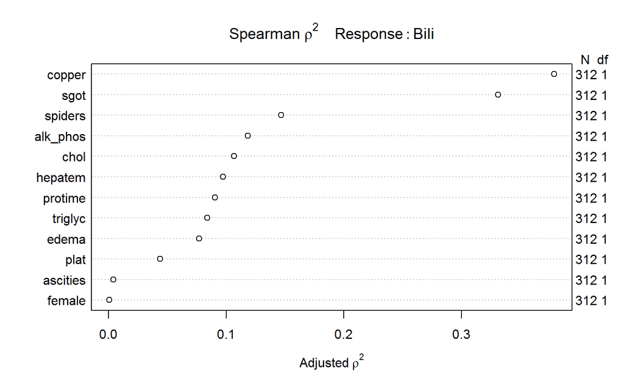

```r
spear.Bili <- spearman2(Bili ~ alk_phos + protime + triglyc + chol + female + copper + sgot + plat + ascities + hepatem + edema + spiders, data = pbc2)

plot(spear.Bili)
```

Here, Copper and SGOT are the two most important variables according to the spearman Rho square plot

# 8 Task 8: My Planned Logistic Regression Model

I plan on having “Ascities” as the binary outcome variable. My other predictors shall be: 1. hepatem 2. Protime 3. Female 4. Status 5. Alkaline Phosphatase.

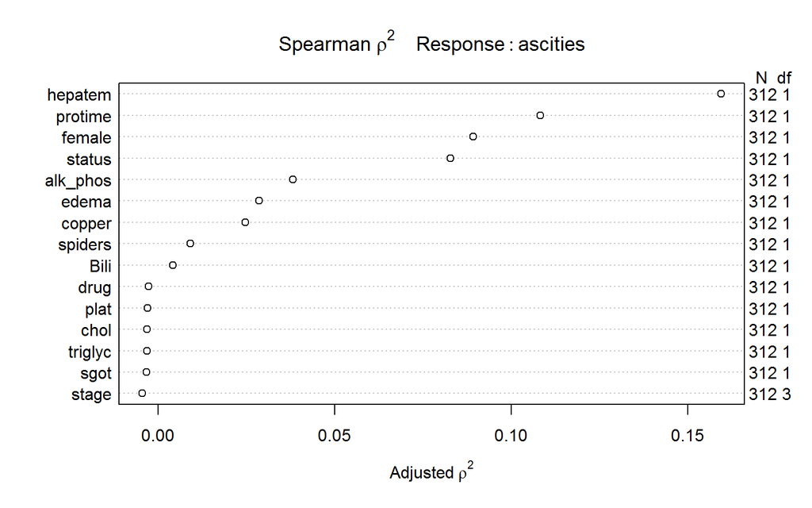

```r
spear.ascities <- spearman2(ascities ~ alk_phos + protime + triglyc + chol + female + copper + sgot + plat + stage + status + Bili + drug + spiders + edema + hepatem, data = pbc2)

plot(spear.ascities)
```

Hepatem is supposed to be the most important variable here, according to the Spearman Rho square plot. The multi-categorical variable is the stage variable. Predictions using stage variable can be made fr ascities.

# 9 Task 9: Affirmation

The dataset fulfills all the necessary requirements of the project. It has more than 100 observations in 19 variables.

I am certain that it is completely appropriate for this data to be shared with anyone, without any conditions. There are no concerns about privacy or security.

# 10 Task 10: Linear Regression

## 10.1 Exploratory Analysis

```r
skim(pbc2)
```

```
Skim summary statistics
 n obs: 312
 n variables: 19

Variable type: character
 variable missing complete   n min max empty n_unique
     drug       0      312 312   7  15     0        2

Variable type: factor
 variable missing complete   n n_unique
    edema       0      312 312        2
    stage       0      312 312        4
   status       0      312 312        2
                           top_counts ordered
             No : 230, Ede: 82, NA: 0   FALSE
 Adv: 120, Ext: 109, Mid: 67, Ear: 16   FALSE
            Cen: 187, Dea: 125, NA: 0   FALSE

Variable type: integer
 variable missing complete   n    mean      sd p0     p25 median     p75
 ascities       0      312 312    0.65    0.48  0    0       1      1
   female       0      312 312    0.88    0.32  0    1       1      1
  fu.days       0      312 312 2006.36 1123.28 41 1191    1839.5 2697.25
  hepatem       0      312 312    0.21    0.41  0    0       0      0
       ID       0      312 312  156.5    90.21  1   78.75  156.5  234.25
  spiders       0      312 312    0.44    0.5   0    0       0      1
 p100     hist
    1 ▅▁▁▁▁▁▁▇
    1 ▁▁▁▁▁▁▁▇
 4556 ▃▆▇▆▆▃▂▂
    1 ▇▁▁▁▁▁▁▂
  312 ▇▇▇▇▇▇▇▇
    1 ▇▁▁▁▁▁▁▆

Variable type: numeric
 variable missing complete   n    mean      sd     p0    p25  median
      alb       0      312 312    3.52    0.42   1.96   3.31    3.55
 alk_phos       0      312 312 1982.66 2140.39 289    871.5  1259
     Bili       0      312 312    3.28    4.53   0.3    0.8     1.4
     chol       0      312 312  364.58  223.86 120    249.5   308.5
   copper       0      312 312   97.55   85.38   4     41.75   73
     plat       0      312 312  261.87   95.44  62    199.75  258
  protime       0      312 312   10.73    1      9     10      10.6
     sgot       0      312 312  122.56   56.7   26.35  80.6   114.7
  triglyc       0      312 312  122.33   63.09  33     84     108
    p75     p100     hist
    3.8     4.64 ▁▁▁▃▇▆▃▁
 1980   13862.4  ▇▂▁▁▁▁▁▁
    3.5    28    ▇▂▁▁▁▁▁▁
  396    1775    ▇▅▁▁▁▁▁▁
  123     588    ▇▃▂▁▁▁▁▁
  322.5   563    ▂▅▇▇▅▂▁▁
   11.1    17.1  ▅▇▃▁▁▁▁▁
  151.9   457.25 ▅▇▅▂▁▁▁▁
  146     598    ▇▇▂▁▁▁▁▁
```

I then checked whether this was a normal distribution or not.

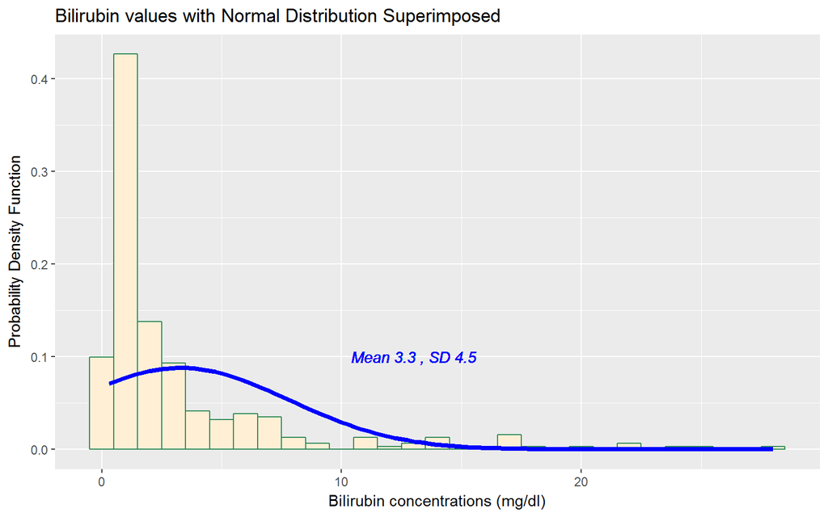

```r
ggplot(pbc2, aes(x=Bili)) +
geom_histogram(aes(y = ..density..), binwidth=1, fill = "papayawhip", color = "seagreen") +    stat_function(fun = dnorm,
args = list(mean = mean(pbc2$Bili),                                                    sd = sd(pbc2$Bili)),
  lwd = 1.5, col = "blue") +
geom_text(aes(label = paste("Mean", round(mean(pbc2$Bili),1),
                                  ", SD", round(sd(pbc2$Bili),1))),
                x = 13, y = 0.1, color="blue", fontface = "italic") +
    labs(title = "Bilirubin values with Normal Distribution Superimposed",
           x = "Bilirubin concentrations (mg/dl)", y = "Probability Density Function")
```

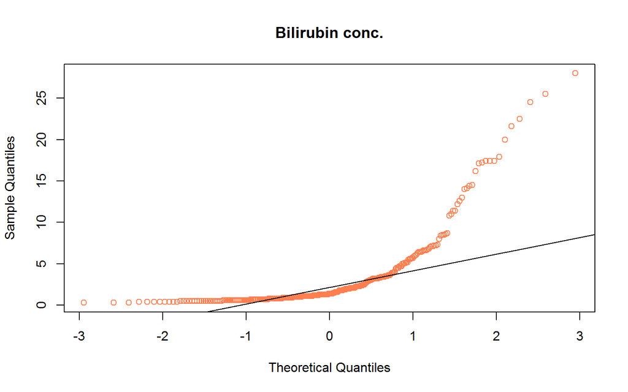

```r
# Checking the QQ plot

qqnorm(pbc2$Bili, main="Bilirubin conc.", col="coral")
qqline(pbc2$Bili)
```

As we can see, the histogram and the QQ plot show that the distribution is not normal. Thus, I made a box cox plot to check for the Y1 value.

### 10.1.1 Transformation

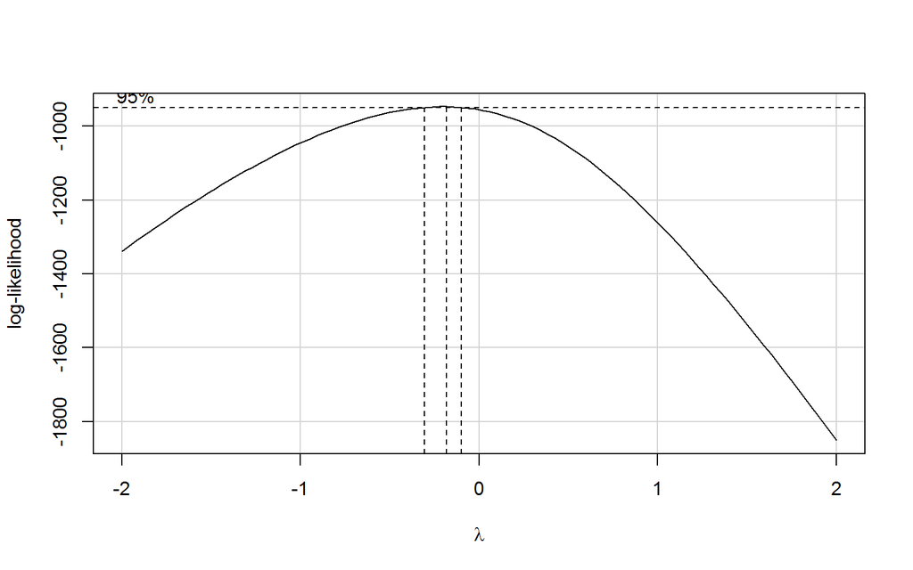

```r
boxCox(lm(Bili ~ copper + female + sgot + alk_phos + stage + drug + hepatem + protime + plat + triglyc + alb, data=pbc2))
```

```r
powerTransform(lm(Bili ~ copper + female + sgot + alk_phos + stage + drug + hepatem + protime + plat + triglyc + alb, data=pbc2))
```

```
Estimated transformation parameters
        Y1
-0.2016253
```

The Y1 value was found to be -0.2, which is closest to 0. Therefore, I converted the Bilirubin values into its natural logarithm.

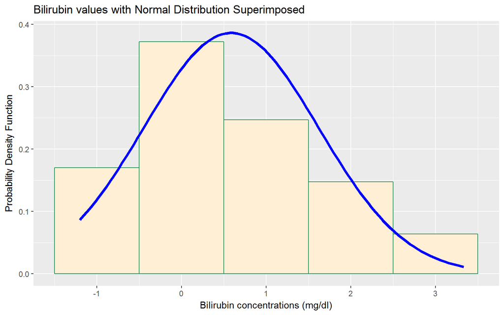

```r
pbc4 <- pbc2
pbc4 <- pbc4 %>% mutate(Bili = log(Bili))
ggplot(pbc4, aes(x=Bili)) +
geom_histogram(aes(y = ..density..), binwidth=1,
                     fill = "papayawhip", color = "seagreen") +
      stat_function(fun = dnorm,
                    args = list(mean = mean(pbc4$Bili),
                                sd = sd(pbc4$Bili)),
                    lwd = 1.5, col = "blue") +
      geom_text(aes(label = paste("Mean", round(mean(pbc4$Bili),1),
                                  ", SD", round(sd(pbc4$Bili),1))),
                x = 13, y = 0.1, color="blue", fontface = "italic") +
     labs(title = "Bilirubin values with Normal Distribution Superimposed",
           x = "Bilirubin concentrations (mg/dl)", y = "Probability Density Function")
```

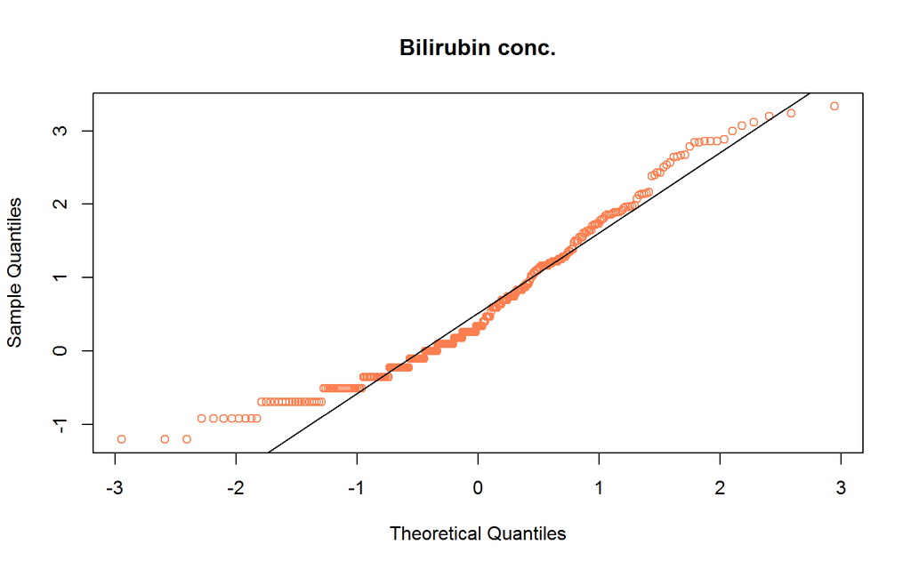

```r
# Now, I checked whether transformation had an effect on the Q-Q plot or not.


qqnorm(pbc4$Bili, main="Bilirubin conc.", col="coral")
qqline(pbc4$Bili)
```

Hence, I proceeded with the transformed values to make my model.

## 10.2 First Model: Kitchen Sink

I first made a Kitchen Sink Model

```r
# Kitchen sink
model_ks <- lm(Bili~copper + female + sgot + alk_phos + stage + drug + hepatem + protime + plat + triglyc + alb, data = pbc4)
```

I then decided to reduce the number of variables, since the degrees of freedom used in the kitchen sink model would be high.

```r
# Stepwise Forward Regression
with(pbc4,
     step(lm(Bili ~ 1),
           scope=(~ copper + female + sgot + alk_phos + stage + drug + hepatem + protime + plat + triglyc + alb), direction="forward"))
```

```
Start:  AIC=21.47
Bili ~ 1

           Df Sum of Sq    RSS     AIC
+ sgot      1    94.259 237.83 -80.696
+ copper    1    93.561 238.53 -79.781
+ alb       1    47.574 284.51 -24.775
+ triglyc   1    42.435 289.65 -19.190
+ stage     3    44.880 287.21 -17.835
+ protime   1    38.026 294.06 -14.477
+ hepatem   1    35.068 297.02 -11.354
+ plat      1    10.847 321.24  13.105
+ alk_phos  1     7.412 324.67  16.423
<none>                  332.09  21.466
+ drug      1     0.608 331.48  22.894
+ female    1     0.378 331.71  23.110

Step:  AIC=-80.7
Bili ~ sgot

           Df Sum of Sq    RSS      AIC
+ copper    1    50.929 186.90 -153.881
+ triglyc   1    30.429 207.40 -121.410
+ protime   1    26.109 211.72 -114.979
+ hepatem   1    25.757 212.07 -114.460
+ stage     3    28.105 209.72 -113.934
+ alb       1    23.821 214.01 -111.624
+ plat      1     4.725 233.10  -84.958
+ alk_phos  1     2.701 235.13  -82.259
<none>                  237.83  -80.696
+ female    1     0.346 237.48  -79.151
+ drug      1     0.138 237.69  -78.878

Step:  AIC=-153.88
Bili ~ sgot + copper

           Df Sum of Sq    RSS     AIC
+ protime   1   14.3005 172.60 -176.72
+ hepatem   1   14.2369 172.66 -176.60
+ triglyc   1   14.2303 172.67 -176.59
```

[output cut: 52 more lines]

```
+ stage     3   3.05316 143.43 -222.48
<none>                  146.48 -221.91
+ alk_phos  1   0.50304 145.98 -220.98
+ female    1   0.19857 146.28 -220.33
+ drug      1   0.10287 146.38 -220.12

Step:  AIC=-223.07
Bili ~ sgot + copper + protime + triglyc + alb + hepatem + plat

           Df Sum of Sq    RSS     AIC
<none>                  145.00 -223.07
+ stage     3   2.49314 142.51 -222.48
+ female    1   0.35532 144.65 -221.83
+ alk_phos  1   0.24380 144.76 -221.59
+ drug      1   0.14560 144.86 -221.38
```

```
Call:
lm(formula = Bili ~ sgot + copper + protime + triglyc + alb +
    hepatem + plat)

Coefficients:
(Intercept)         sgot       copper      protime      triglyc
 -1.4021439    0.0067010    0.0032284    0.1582353    0.0036073
        alb      hepatem         plat
 -0.3244971    0.2511950   -0.0007621
```

The variables obtained from forward regression were: sgot, copper, Protime, triglyc, alb, hepatem, plat.

I then made a model using these variables:

```r
model_fw2 <- lm(Bili~ sgot + copper + protime + triglyc + alb + hepatem + plat, data = pbc4)
summary(model_fw2)
```

```
Call:
lm(formula = Bili ~ sgot + copper + protime + triglyc + alb +
    hepatem + plat, data = pbc4)

Residuals:
     Min       1Q   Median       3Q      Max
-1.75768 -0.44398 -0.04732  0.42181  2.18988

Coefficients:
              Estimate Std. Error t value Pr(>|t|)
(Intercept) -1.4021439  0.6453766  -2.173 0.030583 *
sgot         0.0067010  0.0007341   9.129  < 2e-16 ***
copper       0.0032284  0.0005163   6.253 1.36e-09 ***
protime      0.1582353  0.0431831   3.664 0.000293 ***
triglyc      0.0036073  0.0006627   5.443 1.08e-07 ***
alb         -0.3244971  0.1018311  -3.187 0.001589 **
hepatem      0.2511950  0.1055180   2.381 0.017901 *
plat        -0.0007621  0.0004330  -1.760 0.079407 .
---
Signif. codes:  0 '***' 0.001 '**' 0.01 '*' 0.05 '.' 0.1 ' ' 1

Residual standard error: 0.6906 on 304 degrees of freedom
Multiple R-squared:  0.5634,    Adjusted R-squared:  0.5533
F-statistic: 56.03 on 7 and 304 DF,  p-value: < 2.2e-16
```

The R square value was found to be 0.56, and sgot, copper, protime, triglyc were seen to significantly affect the Bilirubin concetrations.

I then compared the Forward regression model with the Kitchen Sink Model